# OGEI Data Analysis

March 31, 2016

# 1 Introduction

This report summarizes the data analysis performed on the OGEI database (dated March 30, 2016). The data analysis covers all of the inputs which will be used to perform equipment-based calculations in the R model. The primary data analysis method used is to create a cumulative probability table (CPT) by:

1. Selecting the columns containing inputs variables needed for performing the equipment-based emissions calculations from each OGEI database table.
2. Find all unique combinations of the selected input variables.
3. Count the number or times each unique combination appears in the table.
4. Calculate the cumulative probability for each combination.

For example, if the input variables in a table were:

| input1 | input2 |
| --- | --- |
| a | 1 |
| a | 1 |
| a | 1 |
| b | 2 |
| b | 1 |
| c | 3 |

Then the CPT for that table would be (cprob = cumulative probability):

| input1 | input2 | count | fraction | cprob |
| --- | --- | --- | --- | --- |
| a | 1 | 3 | 0.500 | 0.500 |
| b | 2 | 1 | 0.167 | 0.667 |
| b | 1 | 1 | 0.167 | 0.833 |
| c | 3 | 1 | 0.167 | 1.000 |

The motivation for using a CPT is two-fold. First, CPTs fit with the rest of the Monte-Carlo simulation’s structure (randomly picking a number between 0 and 1 and finding the corresponding value from a table or cumulative distribution function (CDF)). Second, CPTs safeguard against independently picking values for input variables that should be correlated. As an example of this second point, consider the emission factors reported by operators for RICE and turbines, which can be any combination of AP 42, NSPS JJJJ, stack test, or manufacturer specification (for each pollutant category). If each reported emission factor were described using a CDF, then during simulations random selections from each CDF might produce combinations that are never observed in the OGEI database (e.g. a low PM2.5 but high PM10 emission factor). Given the differences in emission factors between each unique RICE or turbine, treating all inputs for that equipment category in combination is a more representative approach.

Finally, given that the Monte-Carlo simulation is based on a well-by-well analysis, we need a method to determine the well-by-well contribution to the reported emissions from a each facility in the OGEI database. Using the **operator_id** and **facility_id** keys in the database, the number of unique well API numbers associated with facility were determined from the **apis** table. Taking the inverse of this well count gives the average per-well contribution to the emissions at each operator/facility combination. This is reported in the tables below as **wfrac**, and during the Monte-Carlo simulation it the calculated emissions for each well will be = (emissions from randomly selected facility) * (wfrac for same facility).

# 2 Data Analysis Results

A summary of the data analysis results for each equipment category are given in the following subsections.

## 2.1 Well Completion

Input variables:

```
## [1] "annual_diesel_usage" "flare_efficiency"    "pct_control"
```

Dimensions of **well_completions** table:

- Original: 470 rows
- CPT: 228 rows

First 10 rows of CPT table:

| annual_diesel_usage | flare_efficiency | pct_control | count | cprob |
| --- | --- | --- | --- | --- |
| 1370.000 | No Control | 0 | 141 | 0.300 |
| 5514.203 | No Control | 0 | 59 | 0.426 |
| 172.400 | No Control | 0 | 12 | 0.451 |
| 5600.000 | No Control | 0 | 8 | 0.468 |
| 4800.000 | No Control | 0 | 6 | 0.481 |
| 7200.000 | No Control | 0 | 4 | 0.489 |
| 40.000 | No Control | 0 | 2 | 0.494 |
| 698.000 | No Control | 0 | 2 | 0.498 |
| 704.000 | No Control | 0 | 2 | 0.502 |
| 745.500 | No Control | 0 | 2 | 0.506 |

Summary of inputs (for numerical values):

```
##  annual_diesel_usage  pct_control     count
##  Min.   :    40      Min.   :0    Min.   :  1.000
##  1st Qu.:  2448      1st Qu.:0    1st Qu.:  1.000
##  Median :  3348      Median :0    Median :  1.000
##  Mean   :  8875      Mean   :0    Mean   :  2.061
##  3rd Qu.:  4667      3rd Qu.:0    3rd Qu.:  1.000
##  Max.   :180241      Max.   :0    Max.   :141.000
```

Unique values of character string columns:

- flare efficiency: No Control

CDF plot(s) for interesting input variables:

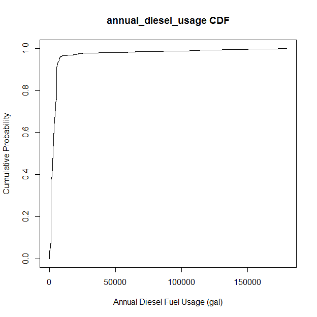

## 2.2 RICE and Turbines

Input variables (note: f[pollutant] column names indicate the numerical value of the emissions factor and u[pollutant] the units associated with that value):

```
##  [1] "horsepower"      "annual_hours"    "total_combusted"
##  [4] "fuel_heating"    "control_type"    "control_pm10"
##  [7] "control_pm25"    "control_sox"     "control_nox"
## [10] "control_voc"     "control_co"      "control_ch2o"
## [13] "wfrac"           "fpm10"           "upm10"
## [16] "fpm25"           "upm25"           "fsox"
## [19] "usox"            "fnox"            "unox"
## [22] "fvoc"            "uvoc"            "fco"
## [25] "uco"             "fch2o"           "uch2o"
```

First 10 rows of CPT table:

| horsepower | annual_hours | total_combusted | fuel_heating | control_type | control_pm10 |
| --- | --- | --- | --- | --- | --- |
| 40 | 8760 | 4.569 | 1020 | Uncontrolled | 0 |
| 32 | 8760 | 2.844 | 1020 | Uncontrolled | 0 |
| 24 | 8760 | 2.178 | 1020 | Uncontrolled | 0 |
| 40 | 8760 | 2.807 | 1236 | Uncontrolled | 0 |
| 65 | 8760 | 4.330 | 1236 | Uncontrolled | 0 |
| 24 | 8760 | 2.178 | 1020 | Uncontrolled | 0 |
| 19 | 8760 | 1.967 | 1100 | Uncontrolled | 0 |
| 24 | 8760 | 2.178 | 1020 | Uncontrolled | 0 |
| 40 | 8064 | 4.206 | 1020 | Uncontrolled | 0 |
| 24 | 8760 | 2.178 | 1020 | Uncontrolled | 0 |

| control_pm25 | control_sox | control_nox | control_voc | control_co | control_ch2o |
| --- | --- | --- | --- | --- | --- |
| 0 | 0 | 0 | 0 | 0 | 0 |
| 0 | 0 | 0 | 0 | 0 | 0 |
| 0 | 0 | 0 | 0 | 0 | 0 |
| 0 | 0 | 0 | 0 | 0 | 0 |
| 0 | 0 | 0 | 0 | 0 | 0 |
| 0 | 0 | 0 | 0 | 0 | 0 |
| 0 | 0 | 0 | 0 | 0 | 0 |
| 0 | 0 | 0 | 0 | 0 | 0 |
| 0 | 0 | 0 | 0 | 0 | 0 |
| 0 | 0 | 0 | 0 | 0 | 0 |

| wfrac | fpm10 | upm10 | fpm25 | upm25 | fsox |
| --- | --- | --- | --- | --- | --- |
| 1.000 | 0.038 | lb/mmbtu | 0.038 | lb/mmbtu | 0.001 |
| 1.000 | 0.010 | lb/mmbtu | 0.010 | lb/mmbtu | 0.001 |
| 0.250 | 0.010 | lb/mmbtu | 0.010 | lb/mmbtu | 0.001 |
| 1.000 | 0.038 | lb/mmbtu | 0.038 | lb/mmbtu | 0.001 |
| 0.333 | 0.038 | lb/mmbtu | 0.038 | lb/mmbtu | 0.001 |
| 0.500 | 0.010 | lb/mmbtu | 0.010 | lb/mmbtu | 0.001 |
| 1.000 | 0.010 | lb/mmbtu | 0.010 | lb/mmbtu | 0.001 |
| 1.000 | 0.010 | lb/mmbtu | 0.010 | lb/mmbtu | 0.001 |
| 1.000 | 0.038 | lb/mmbtu | 0.038 | lb/mmbtu | 0.001 |
| 0.333 | 0.010 | lb/mmbtu | 0.010 | lb/mmbtu | 0.001 |

| usox | fnox | unox | fvoc | uvoc | fco |
| --- | --- | --- | --- | --- | --- |
| lb/mmbtu | 4.40 | g/hp-hr | 0.500 | g/hp-hr | 3.300 |
| lb/mmbtu | 0.40 | g/hp-hr | 0.030 | lb/mmbtu | 2.000 |
| lb/mmbtu | 4.40 | g/hp-hr | 0.030 | lb/mmbtu | 3.400 |
| lb/mmbtu | 4.40 | g/hp-hr | 1.300 | g/hp-hr | 3.300 |
| lb/mmbtu | 2.80 | g/hp-hr | 0.510 | g/hp-hr | 4.800 |
| lb/mmbtu | 4.40 | g/hp-hr | 0.030 | lb/mmbtu | 3.400 |
| lb/mmbtu | 2.76 | g/hp-hr | 0.005 | g/hp-hr | 0.482 |
| lb/mmbtu | 4.40 | g/hp-hr | 0.030 | lb/mmbtu | 3.400 |
| lb/mmbtu | 4.40 | g/hp-hr | 0.500 | g/hp-hr | 3.300 |
| lb/mmbtu | 4.40 | g/hp-hr | 0.030 | lb/mmbtu | 3.400 |

| uco | fch2o | uch2o | count | cprob |
| --- | --- | --- | --- | --- |
| g/hp-hr | 0.300 | g/hp-hr | 126 | 0.041 |
| g/hp-hr | 0.020 | lb/mmbtu | 63 | 0.062 |
| g/hp-hr | 0.020 | lb/mmbtu | 56 | 0.081 |
| g/hp-hr | 0.300 | g/hp-hr | 56 | 0.099 |
| g/hp-hr | 0.055 | lb/mmbtu | 46 | 0.114 |
| g/hp-hr | 0.020 | lb/mmbtu | 43 | 0.128 |
| g/hp-hr | 0.020 | lb/mmbtu | 36 | 0.140 |
| g/hp-hr | 0.020 | lb/mmbtu | 35 | 0.152 |
| g/hp-hr | 0.300 | g/hp-hr | 35 | 0.163 |
| g/hp-hr | 0.020 | lb/mmbtu | 28 | 0.172 |

Summary of inputs (for numerical values):

```
##    horsepower       annual_hours  total_combusted    fuel_heating
##  Min.   :   9.00   Min.   :   0   Min.   :  0.000   Min.   :1000
##  1st Qu.:  40.00   1st Qu.:7170   1st Qu.:  2.253   1st Qu.:1200
##  Median :  40.00   Median :8328   Median :  2.844   Median :1236
##  Mean   :  58.79   Mean   :7462   Mean   :  3.753   Mean   :1193
##  3rd Qu.:  65.00   3rd Qu.:8639   3rd Qu.:  4.190   3rd Qu.:1236
##  Max.   :1680.00   Max.   :8760   Max.   :103.304   Max.   :1493
##   control_pm10  control_pm25  control_sox         control_nox
##  Min.   :0     Min.   :0     Min.   :0.0000000   Min.   :0.000000
##  1st Qu.:0     1st Qu.:0     1st Qu.:0.0000000   1st Qu.:0.000000
##  Median :0     Median :0     Median :0.0000000   Median :0.000000
##  Mean   :0     Mean   :0     Mean   :0.0006181   Mean   :0.001867
##  3rd Qu.:0     3rd Qu.:0     3rd Qu.:0.0000000   3rd Qu.:0.000000
##  Max.   :0     Max.   :0     Max.   :0.9500000   Max.   :0.960000
##   control_voc          control_co        control_ch2o
##  Min.   :0.0000000   Min.   :0.000000   Min.   :0.000000
##  1st Qu.:0.0000000   1st Qu.:0.000000   1st Qu.:0.000000
##  Median :0.0000000   Median :0.000000   Median :0.000000
##  Mean   :0.0006181   Mean   :0.001815   Mean   :0.001698
##  3rd Qu.:0.0000000   3rd Qu.:0.000000   3rd Qu.:0.000000
##  Max.   :0.9500000   Max.   :0.950000   Max.   :0.950000
##      wfrac             fpm10               fpm25
##  Min.   :0.01471   Min.   :0.0000771   Min.   :0.0000771
##  1st Qu.:0.33333   1st Qu.:0.0384000   1st Qu.:0.0384000
##  Median :0.50000   Median :0.0384000   Median :0.0384000
##  Mean   :0.69163   Mean   :0.0331707   Mean   :0.0331707
##  3rd Qu.:1.00000   3rd Qu.:0.0384000   3rd Qu.:0.0384000
##  Max.   :1.00000   Max.   :0.0384000   Max.   :0.0384000
##       fsox                fnox             fvoc             fco
##  Min.   :0.0005880   Min.   : 0.160   Min.   :0.0010   Min.   : 0.100
##  1st Qu.:0.0005880   1st Qu.: 2.800   1st Qu.:0.5000   1st Qu.: 3.300
##  Median :0.0005880   Median : 3.170   Median :0.5100   Median : 3.400
##  Mean   :0.0005917   Mean   : 3.719   Mean   :0.7276   Mean   : 4.038
##  3rd Qu.:0.0005880   3rd Qu.: 4.400   3rd Qu.:1.3000   3rd Qu.: 4.800
##  Max.   :0.0034000   Max.   :23.320   Max.   :4.0000   Max.   :42.300
##      fch2o             count
##  Min.   :0.00071   Min.   :  1.000
##  1st Qu.:0.05520   1st Qu.:  1.000
##  Median :0.05520   Median :  1.000
##  Mean   :0.16520   Mean   :  1.979
##  3rd Qu.:0.30000   3rd Qu.:  2.000
##  Max.   :0.31000   Max.   :126.000
```

Unique values of character string columns:

- control type: Uncontrolled, Controlled
- upm10: lb/mmbtu
- upm25: lb/mmbtu
- usox: lb/mmbtu
- unox: g/hp-hr, lb/mmbtu
- uvoc: g/hp-hr, lb/mmbtu
- uco: g/hp-hr, lb/mmbtu
- uch2o: g/hp-hr, lb/mmbtu, g/ph-hr

CDF plot(s) for interesting input variables:

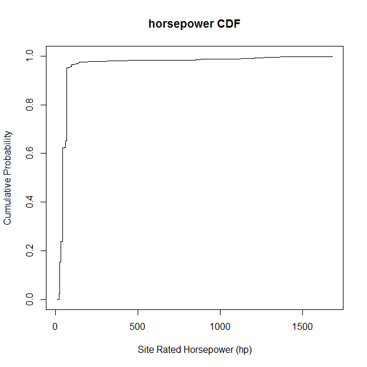

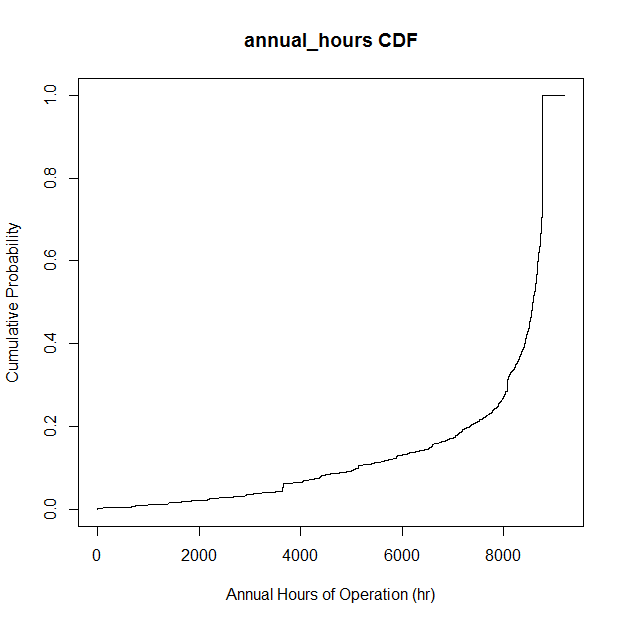

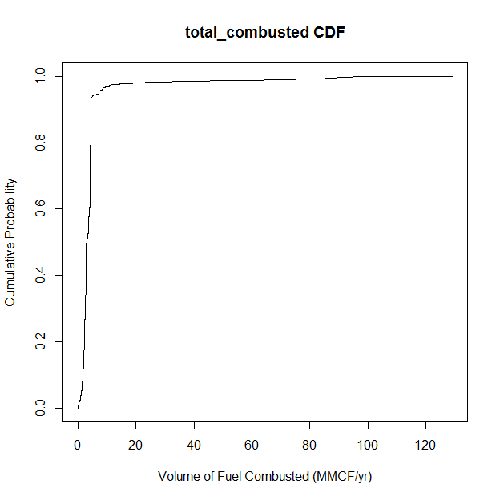

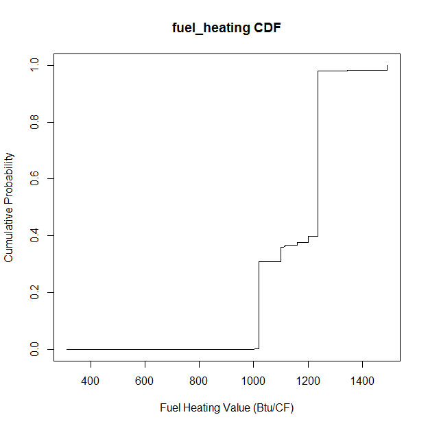

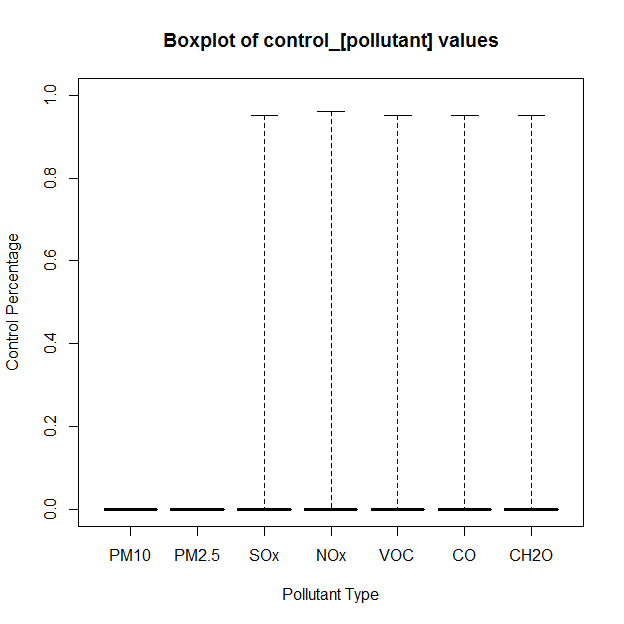

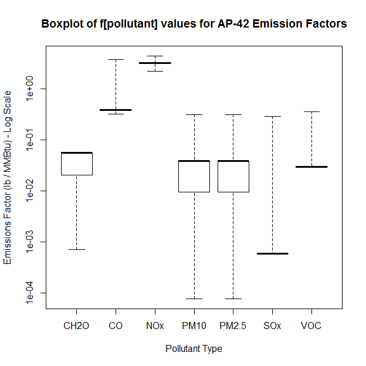

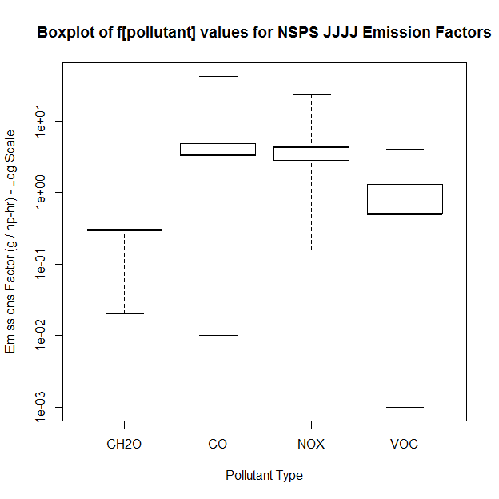

## 2.3 Separators and Heaters

Input variables:

```
## [1] "heat_duty"       "hours_operation" "fuel_heat"       "control_status"
## [5] "percent_control"
```

Dimensions of **separators_heaters** table:

- Original: 7290 rows
- CPT: 2032 rows

First 10 rows of CPT table:

| heat_duty | hours_operation | fuel_heat | control_status | percent_control | wfrac | count | cprob |
| --- | --- | --- | --- | --- | --- | --- | --- |
| 0.25 | 8760 | 1109.17 | Uncontrolled | 0 | 1.000 | 798 | 0.109 |
| 0.50 | 8760 | 1161.31 | Uncontrolled | 0 | 1.000 | 647 | 0.198 |
| 0.25 | 3624 | 1109.17 | Uncontrolled | 0 | 1.000 | 334 | 0.244 |
| 1.00 | 8760 | 1020.00 | Uncontrolled | 0 | 1.000 | 269 | 0.281 |
| 0.15 | 8760 | 1161.31 | Uncontrolled | 0 | 1.000 | 246 | 0.315 |
| 0.25 | 8760 | 1174.50 | Uncontrolled | 0 | 1.000 | 180 | 0.339 |
| 0.50 | 3624 | 1109.17 | Uncontrolled | 0 | 1.000 | 123 | 0.356 |
| 0.25 | 3624 | 1174.50 | Uncontrolled | 0 | 1.000 | 92 | 0.369 |
| 0.25 | 4380 | 1236.00 | Uncontrolled | 0 | 0.333 | 81 | 0.380 |
| 0.50 | 8760 | 1236.00 | Uncontrolled | 0 | 0.333 | 68 | 0.389 |

Summary of inputs (for numerical values):

```
##    heat_duty       hours_operation control_status     percent_control
##  Min.   : 0.0010   Min.   :   0    Length:2032        Min.   :0
##  1st Qu.: 0.2500   1st Qu.:3959    Class :character   1st Qu.:0
##  Median : 0.5000   Median :7329    Mode  :character   Median :0
##  Mean   : 0.6217   Mean   :6125                       Mean   :0
##  3rd Qu.: 0.5000   3rd Qu.:8554                       3rd Qu.:0
##  Max.   :23.8300   Max.   :8760                       Max.   :0
##  NA's   :1         NA's   :1
##      wfrac
##  Min.   :0.01471
##  1st Qu.:0.50000
##  Median :1.00000
##  Mean   :0.75344
##  3rd Qu.:1.00000
##  Max.   :1.00000
##  NA's   :21
```

Unique values of character string columns:

- control status: Uncontrolled

CDF plot(s) for interesting input variables:

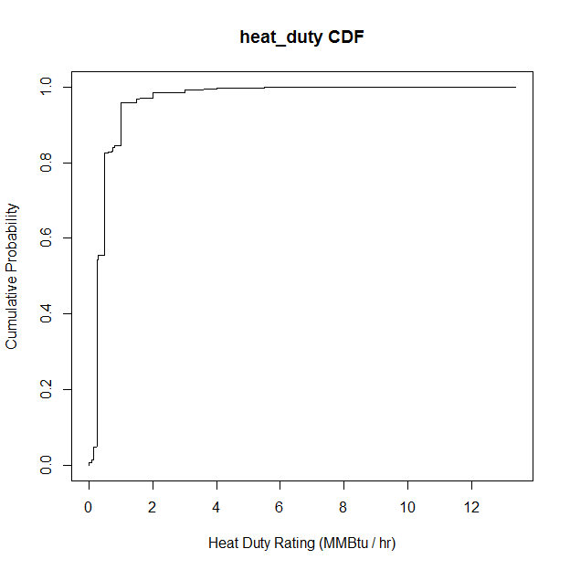

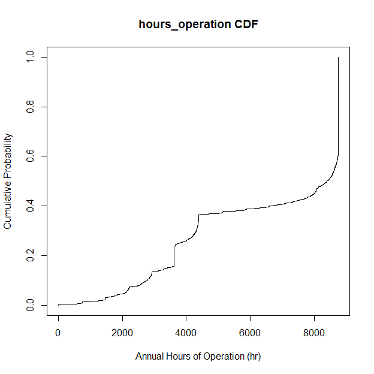

## 2.4 Dehydrators

Input variables:

```
## [1] "hours_operation" "control_type"    "percent_control" "heat_input_rate"
## [5] "pilot_volume"    "factor_voc"      "wfrac"
```

Dimensions of **dehydrators** table:

- Original: 1822 rows
- CPT: 753 rows

First 10 rows of CPT table:

| hours_operation | control_type | percent_control | heat_input_rate | pilot_volume | factor_voc | wfrac | count | cprob |
| --- | --- | --- | --- | --- | --- | --- | --- | --- |
| 0 | No Control | 0 | 0 | 0 | 0.000 | 1 | 27 | 0.015 |
| 8760 | No Control | 0 | 0 | NA | 0.391 | 1 | 15 | 0.023 |
| 8760 | No Control | 0 | 0 | NA | 0.458 | 1 | 13 | 0.030 |
| 8760 | No Control | 0 | 0 | NA | 0.339 | 1 | 11 | 0.036 |
| 8760 | No Control | 0 | 0 | NA | 0.354 | 1 | 11 | 0.042 |
| 8760 | No Control | 0 | 0 | NA | 0.362 | 1 | 11 | 0.048 |
| 8760 | No Control | 0 | 0 | NA | 0.394 | 1 | 11 | 0.054 |
| 8760 | No Control | 0 | 0 | NA | 0.428 | 1 | 11 | 0.060 |
| 8760 | No Control | 0 | 0 | NA | 0.488 | 1 | 11 | 0.066 |
| 8760 | No Control | 0 | 0 | NA | 0.344 | 1 | 10 | 0.072 |

Summary of inputs (for numerical values):

```
##  hours_operation control_type       heat_input_rate    pilot_volume
##  Min.   :   0    Length:753         Min.   :0.00000   Min.   :      0
##  1st Qu.:3576    Class :character   1st Qu.:0.00000   1st Qu.:      0
##  Median :8760    Mode  :character   Median :0.00000   Median :      0
##  Mean   :6698                       Mean   :0.01465   Mean   : 130853
##  3rd Qu.:8760                       3rd Qu.:0.00000   3rd Qu.:      0
##  Max.   :8760                       Max.   :2.30405   Max.   :7008000
##                                                       NA's   :443
##    factor_voc
##  Min.   : 0.0000
##  1st Qu.: 0.4210
##  Median : 0.5162
##  Mean   : 0.7613
##  3rd Qu.: 0.9470
##  Max.   :13.6527
##
```

Unique values of character string columns:

- control type: No Control, Combustor, VRU, Condenser,

CDF plot(s) for interesting input variables:

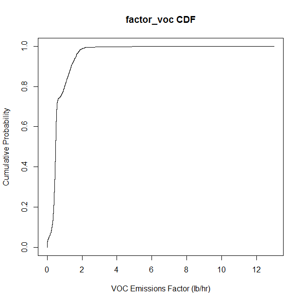

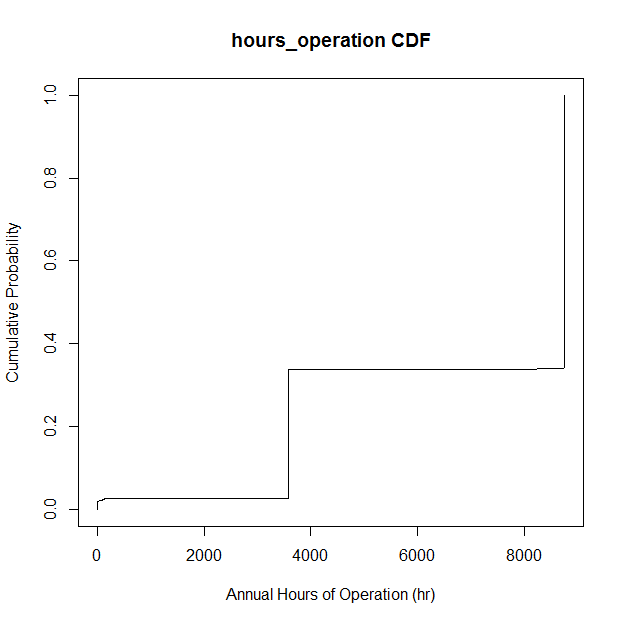

## 2.5 Tanks

Input variables:

```
## [1] "control_type"         "control_percent"      "combustor_heat_input"
## [4] "pilot_volume"         "oil"                  "total_voc"
## [7] "ratio"                "wfrac"
```

First 10 rows of CPT table:

| control_type | control_percent | combustor_heat_input | pilot_volume | oil | total_voc | ratio | wfrac | count | cprob |
| --- | --- | --- | --- | --- | --- | --- | --- | --- | --- |
| No Control | 0.00 | 0 | NA | 11 | 0.000 | 0.000 | 1.000 | 2 | 0.001 |
| Combustor | 0.95 | 0 | 9636 | 5342 | 0.006 | 0.000 | 0.077 | 1 | 0.001 |
| Combustor | 0.98 | 0 | NA | 4 | 0.061 | 0.015 | 1.000 | 1 | 0.002 |
| Combustor | 0.98 | 0 | NA | 6 | 0.000 | 0.000 | 1.000 | 1 | 0.002 |
| Combustor | 0.98 | 0 | NA | 607 | 0.057 | 0.000 | 1.000 | 1 | 0.003 |
| Combustor | 0.98 | 0 | NA | 692 | 0.073 | 0.000 | 1.000 | 1 | 0.003 |
| Combustor | 0.98 | 0 | NA | 734 | 0.113 | 0.000 | 1.000 | 1 | 0.004 |
| Combustor | 0.98 | 0 | NA | 752 | 0.120 | 0.000 | 1.000 | 1 | 0.004 |
| Combustor | 0.98 | 0 | NA | 1044 | 0.000 | 0.000 | 1.000 | 1 | 0.004 |
| Combustor | 0.98 | 0 | NA | 2784 | 0.250 | 0.000 | 1.000 | 1 | 0.005 |

Summary of inputs (for numerical values):

```
##  control_percent   combustor_heat_input  pilot_volume
##  Min.   :0.00000   Min.   :0.000000     Min.   :     0
##  1st Qu.:0.00000   1st Qu.:0.000000     1st Qu.:     0
##  Median :0.00000   Median :0.000000     Median :     0
##  Mean   :0.05704   Mean   :0.003651     Mean   : 14682
##  3rd Qu.:0.00000   3rd Qu.:0.000000     3rd Qu.:     0
##  Max.   :0.98000   Max.   :0.769030     Max.   :271879
##  NA's   :1                              NA's   :1514
##       oil              total_voc            ratio
##  Min.   :     0.04   Min.   : 0.00000   Min.   :0.000000
##  1st Qu.:   922.65   1st Qu.: 0.06968   1st Qu.:0.000016
##  Median :  2601.00   Median : 0.32570   Median :0.000103
##  Mean   :  7151.52   Mean   : 1.59580   Mean   :0.017549
##  3rd Qu.:  7752.61   3rd Qu.: 1.70262   3rd Qu.:0.000765
##  Max.   :218074.33   Max.   :55.47550   Max.   :6.156841
##
##      wfrac             count
##  Min.   :0.03846   Min.   :1
##  1st Qu.:1.00000   1st Qu.:1
##  Median :1.00000   Median :1
##  Mean   :0.93053   Mean   :1
##  3rd Qu.:1.00000   3rd Qu.:1
##  Max.   :1.00000   Max.   :2
##  NA's   :22
```

Unique values of character string columns:

- control type: No Control, Combustor

CDF plot(s) for interesting input variables:

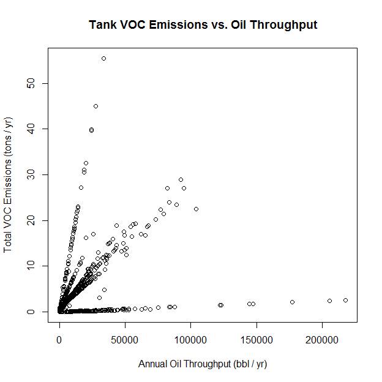

Ideally, in the simulation I’d like to model tank VOC emissions as a function of oil throughput (as contributed by each well). However given the results shown above, that might not be possible, as there are several distinct trendlines through the data set. I haven’t figured out yet what the correlation is between the slope of each line and any of the other columns in the **tanks** table. As is, we can randomly draw from the CPT table, and given our selection, we can apply whatever VOC emissions rate (ton VOC / bbl oil) goes along with tht selection.

## 2.6 Truck Loading

Input variables:

```
## [1] "s_factor"         "vapor_pressure"   "molecular_weight"
## [4] "temp_r"           "control_type"     "control_percent"
```

Dimensions of **truck_loading** table:

- Original: 4253 rows
- CPT: 31 rows

First 10 rows of CPT table:

| s_factor | vapor_pressure | molecular_weight | temp_r | control_type | control_percent | count | cprob |
| --- | --- | --- | --- | --- | --- | --- | --- |
| 0.6 | 2.960 | 50.000 | 620 | No Control | 0 | 1607 | 0.378 |
| 0.6 | 7.000 | 31.800 | 510 | No Control | 0 | 1137 | 0.645 |
| 0.6 | 7.104 | 53.835 | 610 | No Control | 0 | 605 | 0.787 |
| 0.6 | 4.000 | 25.090 | 530 | No Control | 0 | 589 | 0.926 |
| 0.6 | 6.976 | 49.100 | 620 | No Control | 0 | 80 | 0.945 |
| 0.6 | 5.000 | 350.000 | 620 | No Control | 0 | 74 | 0.962 |
| 0.6 | 7.740 | 24.340 | 615 | No Control | 0 | 59 | 0.976 |
| 0.6 | 2.800 | 50.000 | 520 | No Control | 0 | 39 | 0.985 |
| 0.6 | 3.200 | 42.000 | 525 | No Control | 0 | 13 | 0.988 |
| 0.6 | 4.770 | 53.000 | 521 | No Control | 0 | 11 | 0.991 |

Summary of inputs (for numerical values):

```
##     s_factor      vapor_pressure   molecular_weight     temp_r
##  Min.   :0.6000   Min.   : 0.500   Min.   : 23.45   Min.   :481.7
##  1st Qu.:0.6000   1st Qu.: 3.285   1st Qu.: 26.55   1st Qu.:504.7
##  Median :0.6000   Median : 6.030   Median : 33.22   Median :520.0
##  Mean   :0.6258   Mean   : 9.978   Mean   : 48.45   Mean   :534.0
##  3rd Qu.:0.6000   3rd Qu.:19.112   3rd Qu.: 50.00   3rd Qu.:532.5
##  Max.   :1.0000   Max.   :33.124   Max.   :350.00   Max.   :620.0
##  control_percent       count
##  Min.   :0.00000   Min.   :   1.0
##  1st Qu.:0.00000   1st Qu.:   1.0
##  Median :0.00000   Median :   1.0
##  Mean   :0.05806   Mean   : 137.2
##  3rd Qu.:0.00000   3rd Qu.:  26.0
##  Max.   :0.90000   Max.   :1607.0
```

Unique values of character string columns:

- control type: No Control

CDF plot(s) for interesting input variables:

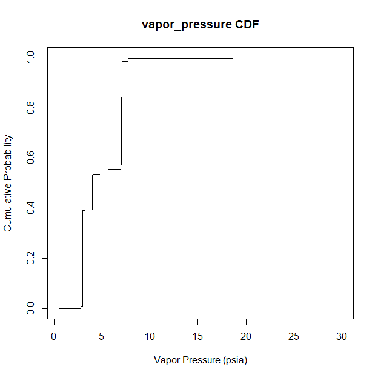

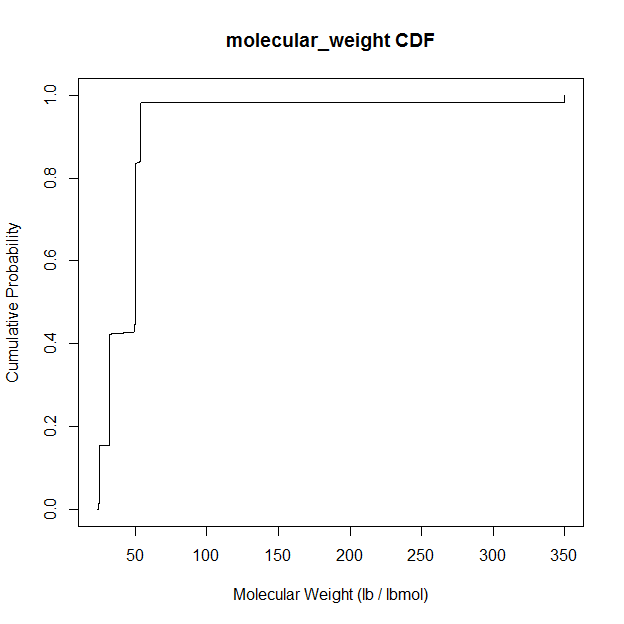

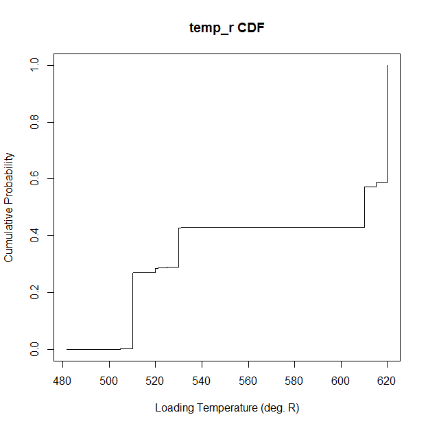

## 2.7 Pneumatic Controllers

Input variables:

```
## [1] "high_bleed"         "intermittent_bleed" "low_bleed"
## [4] "avg_hours"          "wfrac"
```

Dimensions of **pneumatic_controllers** table:

- Original: 4215 rows
- CPT: 1715 rows

First 10 rows of CPT table:

| high_bleed | intermittent_bleed | low_bleed | avg_hours | wfrac | count | cprob |
| --- | --- | --- | --- | --- | --- | --- |
| NA | 6 | NA | 8760 | 1 | 1034 | 0.245 |
| 0 | 8 | 0 | 8760 | 1 | 436 | 0.349 |
| 0 | 2 | 0 | 8760 | 1 | 180 | 0.391 |
| 0 | 7 | 0 | 8760 | 1 | 111 | 0.418 |
| 0 | 2 | 0 | 8064 | 1 | 47 | 0.429 |
| 0 | 3 | 0 | 8760 | 1 | 43 | 0.439 |
| NA | 0 | NA | 8760 | 1 | 40 | 0.449 |
| 2 | NA | NA | 8760 | 1 | 31 | 0.456 |
| NA | 2 | NA | 8760 | 1 | 30 | 0.463 |
| NA | 8 | NA | 8760 | 1 | 25 | 0.469 |

Summary of inputs (for numerical values):

```
##    high_bleed      intermittent_bleed   low_bleed         avg_hours
##  Min.   :0.00000   Min.   : 0.000     Min.   : 0.0000   Min.   :   0
##  1st Qu.:0.00000   1st Qu.: 5.000     1st Qu.: 0.0000   1st Qu.:7176
##  Median :0.00000   Median : 6.000     Median : 0.0000   Median :8322
##  Mean   :0.01523   Mean   : 6.192     Mean   : 0.2529   Mean   :7470
##  3rd Qu.:0.00000   3rd Qu.: 7.000     3rd Qu.: 0.0000   3rd Qu.:8640
##  Max.   :4.00000   Max.   :39.000     Max.   :38.0000   Max.   :8760
##  NA's   :74        NA's   :43         NA's   :46        NA's   :6
##      wfrac             count              cprob
##  Min.   :0.01471   Min.   :   1.000   Min.   :0.2453
##  1st Qu.:0.50000   1st Qu.:   1.000   1st Qu.:0.6950
##  Median :1.00000   Median :   1.000   Median :0.7967
##  Mean   :0.74816   Mean   :   2.458   Mean   :0.7910
##  3rd Qu.:1.00000   3rd Qu.:   1.000   3rd Qu.:0.8983
##  Max.   :1.00000   Max.   :1034.000   Max.   :1.0000
##  NA's   :13
```

There are no character string column types for this table.

CDF plot(s) for interesting input variables:

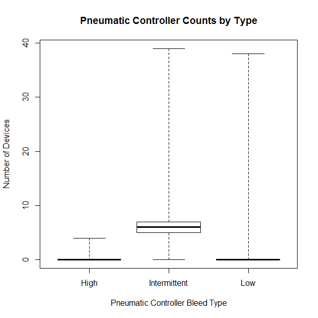

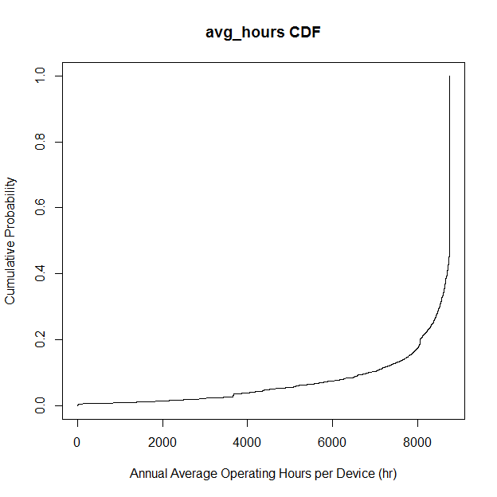

## 2.8 Pneumatic Pumps

Input variables:

```
## [1] "annual_operation" "vent_rate"        "control_type"
## [4] "control_percent"  "gas_mw"           "voc_wt"
## [7] "wfrac"
```

Dimensions of **pneumatic_pumps** table:

- Original: 3196 rows
- CPT: 156 rows

First 10 rows of CPT table:

| annual_operation | vent_rate | control_type | control_percent | gas_mw | voc_wt | wfrac | count | cprob |
| --- | --- | --- | --- | --- | --- | --- | --- | --- |
| 4380 | 3.560 |  | NA | 19.82 | 0.152 | 1 | 1127 | 0.353 |
| 8760 | 0.070 |  | NA | 19.82 | 0.152 | 1 | 600 | 0.540 |
| 3576 | 7.500 | No Control | 0 | 17.96 | 0.090 | 1 | 361 | 0.653 |
| 0 | 0.000 | No Control | 0 | 17.96 | 0.090 | 1 | 280 | 0.741 |
| 8760 | 0.601 | No Control | 0 | 17.96 | 0.090 | 1 | 193 | 0.801 |
| 3576 | 7.500 | No Control | 0 | 19.46 | 0.154 | 1 | 101 | 0.833 |
| 3576 | 10.000 | No Control | 0 | 17.96 | 0.090 | 1 | 69 | 0.855 |
| 0 | 0.000 | No Control | 0 | 19.46 | 0.154 | 1 | 55 | 0.872 |
| 8760 | 0.601 | No Control | 0 | 19.46 | 0.154 | 1 | 54 | 0.889 |
| 8760 | 0.222 | No Control | 0 | 22.00 | 0.104 | 1 | 46 | 0.903 |

Summary of inputs (for numerical values):

```
##  annual_operation   vent_rate       control_percent     gas_mw
##  Min.   :   0     Min.   : 0.0000   Min.   :0       Min.   :17.60
##  1st Qu.:2986     1st Qu.: 0.4361   1st Qu.:0       1st Qu.:17.96
##  Median :5766     Median : 0.6014   Median :0       Median :19.46
##  Mean   :5378     Mean   : 1.7089   Mean   :0       Mean   :19.29
##  3rd Qu.:8300     3rd Qu.: 0.9700   3rd Qu.:0       3rd Qu.:20.14
##  Max.   :8760     Max.   :10.0000   Max.   :0       Max.   :22.00
##  NA's   :4        NA's   :4         NA's   :8       NA's   :4
##      voc_wt           wfrac             count
##  Min.   :0.0380   Min.   :0.02326   Min.   :   1.00
##  1st Qu.:0.0905   1st Qu.:1.00000   1st Qu.:   1.00
##  Median :0.1542   Median :1.00000   Median :   1.00
##  Mean   :0.1459   Mean   :0.95952   Mean   :  20.49
##  3rd Qu.:0.1925   3rd Qu.:1.00000   3rd Qu.:   2.00
##  Max.   :0.2503   Max.   :1.00000   Max.   :1127.00
##                   NA's   :3
```

Unique values of character string columns:

- control type: , No Control

CDF plot(s) for interesting input variables:

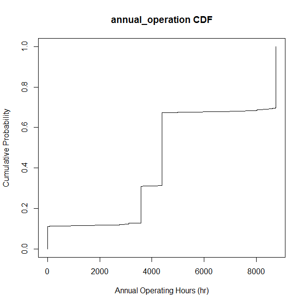

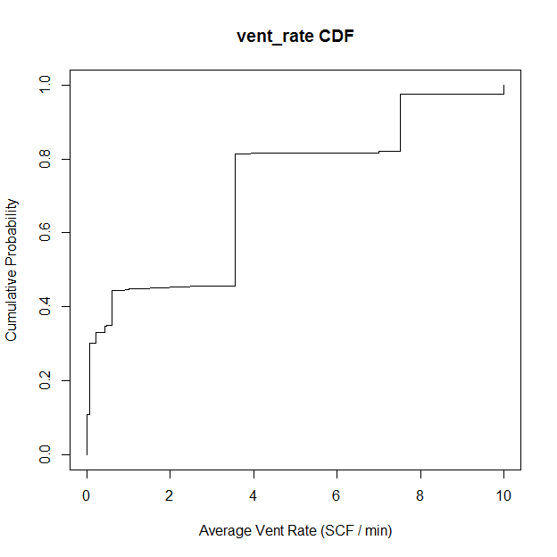

## 2.9 Fugitives

Input variables (for each of the four component types: gas, heavy oil, light oil, and water/oil):

```
## [1] "production_hours" "voc_wt"           "valves"
## [4] "pumpseals"        "other1"           "connectors"
## [7] "flanges"          "open_lines"       "wfrac"
```

Dimensions of **fugitives** table:

- Original: 4340 rows
- CPT: Gas component has 1629 rows, Heavy Oil component has 1389 rows, Light Oil component has 1621 rows, Water/Oil component has 1630 rows

First 10 rows of CPT table for gas component:

| production_hours | voc_wt | valves | pumpseals | other1 | connectors | flanges | open_lines | wfrac | count | cprob |
| --- | --- | --- | --- | --- | --- | --- | --- | --- | --- | --- |
| 8760 | 0.150 | 30 | 0 | 15 | 250 | 8 | 9 | 1.000 | 1127 | 0.260 |
| 8760 | NA | NA | NA | NA | NA | NA | NA | 1.000 | 503 | 0.376 |
| 8760 | 0.250 | 15 | 0 | 25 | 10 | 40 | 1 | 1.000 | 243 | 0.432 |
| 8760 | 0.250 | 8 | 0 | 0 | 13 | 14 | 0 | 1.000 | 57 | 0.445 |
| 8064 | 0.250 | 15 | 0 | 25 | 10 | 40 | 1 | 1.000 | 55 | 0.457 |
| 8760 | 0.250 | 15 | 0 | 25 | 10 | 40 | 1 | 0.500 | 54 | 0.470 |
| 8760 | 0.152 | 59 | NA | 3 | 168 | 25 | 8 | 1.000 | 34 | 0.478 |
| 8760 | 0.250 | 15 | 0 | 25 | 1000 | 25 | 1 | 1.000 | 34 | 0.485 |
| 8760 | 0.204 | 63 | 4 | 26 | 225 | 0 | 8 | 0.500 | 31 | 0.493 |
| 8760 | 0.250 | 15 | 0 | 25 | 10 | 40 | 1 | 0.333 | 23 | 0.498 |

First 10 rows of CPT table for heavy oil component:

| production_hours | voc_wt | valves | pumpseals | other1 | connectors | flanges | open_lines | wfrac | count | cprob |
| --- | --- | --- | --- | --- | --- | --- | --- | --- | --- | --- |
| 8760 | 0.0 | 0 | 0 | 0 | 0 | 0 | 0 | 1.000 | 1142 | 0.263 |
| 8760 | NA | NA | NA | NA | NA | NA | NA | 1.000 | 599 | 0.401 |
| 8760 | 0.1 | 20 | 0 | 2 | 20 | 30 | 2 | 1.000 | 243 | 0.457 |
| 8064 | 0.1 | 20 | 0 | 2 | 20 | 30 | 2 | 1.000 | 55 | 0.470 |
| 8760 | 0.1 | 20 | 0 | 2 | 20 | 30 | 2 | 0.500 | 54 | 0.482 |
| 8760 | 0.1 | 10 | 0 | 10 | 600 | 10 | 5 | 1.000 | 34 | 0.490 |
| 8760 | 1.0 | NA | NA | NA | NA | NA | NA | 1.000 | 34 | 0.498 |
| 8760 | 0.0 | 0 | 0 | 0 | 0 | 0 | 0 | 0.500 | 31 | 0.505 |
| 8760 | NA | NA | NA | NA | NA | NA | NA | 0.333 | 25 | 0.511 |
| 8760 | NA | NA | NA | NA | NA | NA | NA | 0.500 | 25 | 0.517 |

First 10 rows of CPT table for light oil component:

| production_hours | voc_wt | valves | pumpseals | other1 | connectors | flanges | open_lines | wfrac | count | cprob |
| --- | --- | --- | --- | --- | --- | --- | --- | --- | --- | --- |
| 8760 | 0.621 | 40 | 2 | 15 | 200 | 5 | 3 | 1.000 | 1127 | 0.260 |
| 8760 | NA | NA | NA | NA | NA | NA | NA | 1.000 | 505 | 0.376 |
| 8760 | 1.000 | 0 | 0 | 0 | 0 | 0 | 0 | 1.000 | 243 | 0.432 |
| 8760 | 1.000 | 15 | 0 | 1 | 26 | 27 | 0 | 1.000 | 57 | 0.445 |
| 8064 | 1.000 | 0 | 0 | 0 | 0 | 0 | 0 | 1.000 | 55 | 0.458 |
| 8760 | 1.000 | 0 | 0 | 0 | 0 | 0 | 0 | 0.500 | 54 | 0.470 |
| 8760 | 1.000 | 10 | 0 | 10 | 600 | 10 | 5 | 1.000 | 48 | 0.481 |
| 8760 | 1.000 | 40 | 2 | NA | 90 | 10 | 8 | 1.000 | 34 | 0.489 |
| 8760 | 1.000 | 51 | 0 | 4 | 80 | 93 | 0 | 0.500 | 31 | 0.496 |
| 8760 | 1.000 | 0 | 0 | 0 | 0 | 0 | 0 | 0.333 | 23 | 0.502 |

First 10 rows of CPT table for water/oil component:

| production_hours | voc_wt | valves | pumpseals | other1 | connectors | flanges | open_lines | wfrac | count | cprob |
| --- | --- | --- | --- | --- | --- | --- | --- | --- | --- | --- |
| 8760 | 0.621 | 20 | 0 | 6 | 50 | 4 | 3 | 1.000 | 1127 | 0.260 |
| 8760 | 0.010 | 50 | 6 | 10 | 150 | 100 | 5 | 1.000 | 402 | 0.352 |
| 8760 | 1.000 | 5 | 0 | 1 | 10 | 4 | 2 | 1.000 | 243 | 0.408 |
| 8760 | NA | NA | NA | NA | NA | NA | NA | 1.000 | 135 | 0.439 |
| 8760 | 0.500 | 8 | 0 | 0 | 13 | 14 | 0 | 1.000 | 57 | 0.453 |
| 8064 | 1.000 | 5 | 0 | 1 | 10 | 4 | 2 | 1.000 | 55 | 0.465 |
| 8760 | 1.000 | 5 | 0 | 1 | 10 | 4 | 2 | 0.500 | 54 | 0.478 |
| 8760 | 1.000 | 5 | 0 | 5 | 200 | 0 | 2 | 1.000 | 34 | 0.485 |
| 8760 | 1.000 | 51 | 0 | 4 | 80 | 93 | 0 | 0.500 | 31 | 0.493 |
| 8760 | 1.000 | 5 | 0 | 1 | 10 | 4 | 2 | 0.333 | 23 | 0.498 |

Summary of inputs for gas component:

```
##  production_hours     voc_wt           valves         pumpseals
##  Min.   :   0     Min.   :0.0326   Min.   :  6.00   Min.   :0.00000
##  1st Qu.:7054     1st Qu.:0.2500   1st Qu.:  8.00   1st Qu.:0.00000
##  Median :8270     Median :0.2500   Median :  8.00   Median :0.00000
##  Mean   :7403     Mean   :0.2446   Mean   : 11.14   Mean   :0.01557
##  3rd Qu.:8621     3rd Qu.:0.2500   3rd Qu.:  9.00   3rd Qu.:0.00000
##  Max.   :9760     Max.   :0.2800   Max.   :845.00   Max.   :6.00000
##                   NA's   :81       NA's   :81       NA's   :88
##      other1         connectors         flanges         open_lines
##  Min.   : 0.000   Min.   :  10.00   Min.   :   0.0   Min.   :  0.0000
##  1st Qu.: 0.000   1st Qu.:  12.00   1st Qu.:  14.0   1st Qu.:  0.0000
##  Median : 0.000   Median :  13.00   Median :  14.0   Median :  0.0000
##  Mean   : 4.355   Mean   :  70.77   Mean   :  19.6   Mean   :  0.6292
##  3rd Qu.: 0.000   3rd Qu.:  13.00   3rd Qu.:  16.0   3rd Qu.:  0.0000
##  Max.   :48.000   Max.   :1554.00   Max.   :1465.0   Max.   :195.0000
##  NA's   :81       NA's   :81        NA's   :81       NA's   :81
##      wfrac             count              cprob
##  Min.   :0.02326   Min.   :   1.000   Min.   :0.2597
##  1st Qu.:0.50000   1st Qu.:   1.000   1st Qu.:0.7187
##  Median :1.00000   Median :   1.000   Median :0.8124
##  Mean   :0.75757   Mean   :   2.664   Mean   :0.8065
##  3rd Qu.:1.00000   3rd Qu.:   1.000   3rd Qu.:0.9062
##  Max.   :1.00000   Max.   :1127.000   Max.   :1.0000
##  NA's   :11
```

Summary of inputs for heavy oil component:

```
##  production_hours     voc_wt          valves        pumpseals
##  Min.   :   0     Min.   :0.000   Min.   : 0.00   Min.   :0
##  1st Qu.:6888     1st Qu.:0.100   1st Qu.:10.00   1st Qu.:0
##  Median :8208     Median :0.100   Median :20.00   Median :0
##  Mean   :7324     Mean   :0.362   Mean   :16.03   Mean   :0
##  3rd Qu.:8594     3rd Qu.:1.000   3rd Qu.:20.00   3rd Qu.:0
##  Max.   :9760     Max.   :1.000   Max.   :20.00   Max.   :0
##                   NA's   :1134    NA's   :1139    NA's   :1139
##      other1       connectors       flanges        open_lines
##  Min.   : 0.0   Min.   :  0.0   Min.   : 0.00   Min.   :0.00
##  1st Qu.: 2.0   1st Qu.: 20.0   1st Qu.:10.00   1st Qu.:2.00
##  Median : 2.0   Median : 20.0   Median :30.00   Median :2.00
##  Mean   : 4.6   Mean   :209.8   Mean   :22.41   Mean   :2.92
##  3rd Qu.:10.0   3rd Qu.:600.0   3rd Qu.:30.00   3rd Qu.:5.00
##  Max.   :10.0   Max.   :600.0   Max.   :30.00   Max.   :5.00
##  NA's   :1139   NA's   :1139    NA's   :1139    NA's   :1139
##      wfrac             count              cprob
##  Min.   :0.02326   Min.   :   1.000   Min.   :0.2631
##  1st Qu.:0.50000   1st Qu.:   1.000   1st Qu.:0.7601
##  Median :1.00000   Median :   1.000   Median :0.8401
##  Mean   :0.74699   Mean   :   3.125   Mean   :0.8289
##  3rd Qu.:1.00000   3rd Qu.:   1.000   3rd Qu.:0.9200
##  Max.   :1.00000   Max.   :1142.000   Max.   :1.0000
##  NA's   :6
```

Summary of inputs for light oil component:

```
##  production_hours     voc_wt           valves         pumpseals
##  Min.   :   0     Min.   :0.6211   Min.   :  0.00   Min.   : 0.00000
##  1st Qu.:7048     1st Qu.:1.0000   1st Qu.: 15.00   1st Qu.: 0.00000
##  Median :8264     Median :1.0000   Median : 15.00   Median : 0.00000
##  Mean   :7396     Mean   :0.9989   Mean   : 14.71   Mean   : 0.02989
##  3rd Qu.:8616     3rd Qu.:1.0000   3rd Qu.: 17.00   3rd Qu.: 0.00000
##  Max.   :9760     Max.   :1.0000   Max.   :959.00   Max.   :25.00000
##                   NA's   :82       NA's   :82       NA's   :82
##      other1         connectors         flanges         open_lines
##  Min.   : 0.000   Min.   :   0.00   Min.   :   0.0   Min.   : 0.0000
##  1st Qu.: 1.000   1st Qu.:  23.00   1st Qu.:  27.0   1st Qu.: 0.0000
##  Median : 1.000   Median :  26.00   Median :  27.0   Median : 0.0000
##  Mean   : 1.754   Mean   :  54.61   Mean   :  24.7   Mean   : 0.3615
##  3rd Qu.: 2.000   3rd Qu.:  26.00   3rd Qu.:  28.0   3rd Qu.: 0.0000
##  Max.   :15.000   Max.   :1174.00   Max.   :1138.0   Max.   :38.0000
##  NA's   :87       NA's   :83        NA's   :82       NA's   :83
##      wfrac             count              cprob
##  Min.   :0.02326   Min.   :   1.000   Min.   :0.2597
##  1st Qu.:0.50000   1st Qu.:   1.000   1st Qu.:0.7200
##  Median :1.00000   Median :   1.000   Median :0.8134
##  Mean   :0.75724   Mean   :   2.677   Mean   :0.8074
##  3rd Qu.:1.00000   3rd Qu.:   1.000   3rd Qu.:0.9067
##  Max.   :1.00000   Max.   :1127.000   Max.   :1.0000
##  NA's   :10
```

Summary of inputs for water/oil component:

```
##  production_hours     voc_wt           valves        pumpseals
##  Min.   :   0     Min.   :0.0100   Min.   : 4.00   Min.   :0.0000
##  1st Qu.:7046     1st Qu.:0.5000   1st Qu.: 8.00   1st Qu.:0.0000
##  Median :8263     Median :0.5000   Median : 8.00   Median :0.0000
##  Mean   :7396     Mean   :0.5403   Mean   : 9.64   Mean   :0.2377
##  3rd Qu.:8617     3rd Qu.:0.5000   3rd Qu.: 9.00   3rd Qu.:0.0000
##  Max.   :9760     Max.   :1.0000   Max.   :75.00   Max.   :6.0000
##                   NA's   :27       NA's   :27      NA's   :27
##      other1          connectors        flanges         open_lines
##  Min.   : 0.0000   Min.   : 10.00   Min.   :  0.00   Min.   :0.0000
##  1st Qu.: 0.0000   1st Qu.: 12.00   1st Qu.: 14.00   1st Qu.:0.0000
##  Median : 0.0000   Median : 13.00   Median : 14.00   Median :0.0000
##  Mean   : 0.8896   Mean   : 28.66   Mean   : 16.07   Mean   :0.5296
##  3rd Qu.: 0.0000   3rd Qu.: 13.00   3rd Qu.: 14.00   3rd Qu.:0.0000
##  Max.   :40.0000   Max.   :200.00   Max.   :100.00   Max.   :8.0000
##  NA's   :27        NA's   :27       NA's   :27       NA's   :27
##      wfrac             count              cprob
##  Min.   :0.02326   Min.   :   1.000   Min.   :0.2597
##  1st Qu.:0.50000   1st Qu.:   1.000   1st Qu.:0.7185
##  Median :1.00000   Median :   1.000   Median :0.8123
##  Mean   :0.75817   Mean   :   2.663   Mean   :0.8064
##  3rd Qu.:1.00000   3rd Qu.:   1.000   3rd Qu.:0.9062
##  Max.   :1.00000   Max.   :1127.000   Max.   :1.0000
##  NA's   :8
```

There are no character string column types for this table.

CDF plot(s) for interesting input variables:

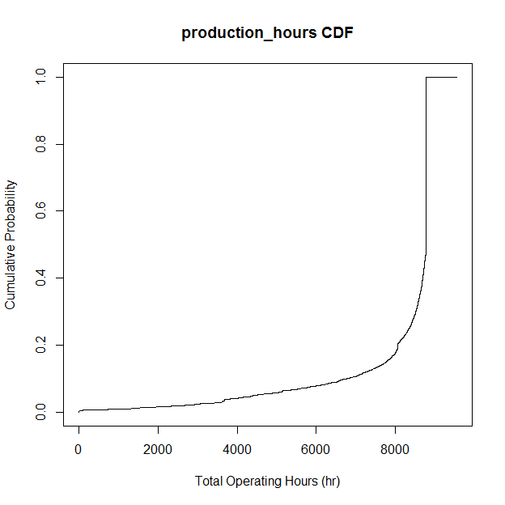

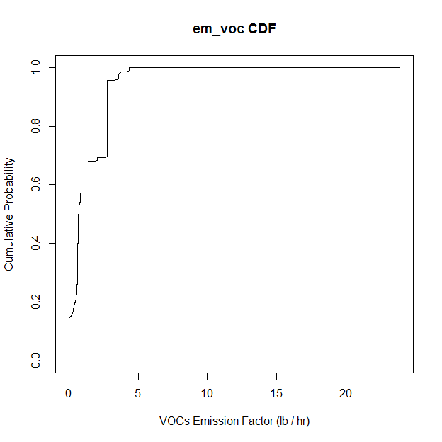